# Understanding the key factors affecting the Life Expectancy of Countries

**In this R task, we are going to use data from the world health organization to answer some important questions related to Life Expectancy, which are given below -**

- Q1 - Does various predicting factors which has been chosen initially really affect the Life expectancy? Are are the predicting variables actually affecting the life expectancy?
- Q2 - Should a country having a lower life expectancy value(<65) increase its healthcare expenditure in order to improve its average lifespan?
- Q3 - How does Infant and Adult mortality rates affect life expectancy?
- Q4 - What is the impact of schooling on the lifespan of humans?
- Q5 - Does Life Expectancy have positive or negative relationship with drinking alcohol?
- Q6 - Do densely populated countries tend to have lower life expectancy?
- Q7 - What is the impact of Immunization coverage on life Expectancy?

### Importing the dataset to use

```r
data = read.csv('WHO.csv')
attach(data)
```

### Understanding the data structure

```r
library(tidyr)
library(dplyr)
head(data)
```

```
##       Country Year     Status Lifeexpectancy AdultMortality infantdeaths
## 1 Afghanistan 2015 Developing           65.0            263           62
## 2 Afghanistan 2014 Developing           59.9            271           64
## 3 Afghanistan 2013 Developing           59.9            268           66
## 4 Afghanistan 2012 Developing           59.5            272           69
## 5 Afghanistan 2011 Developing           59.2            275           71
## 6 Afghanistan 2010 Developing           58.8            279           74
##   Alcohol percentageexpenditure HepatitisB Measles  BMI under.fivedeaths Polio
## 1    0.01             71.279624         65    1154 19.1               83     6
## 2    0.01             73.523582         62     492 18.6               86    58
## 3    0.01             73.219243         64     430 18.1               89    62
## 4    0.01             78.184215         67    2787 17.6               93    67
## 5    0.01              7.097109         68    3013 17.2               97    68
## 6    0.01             79.679367         66    1989 16.7              102    66
##   Totalexpenditure Diphtheria HIV.AIDS       GDP Population thinness1.19years
## 1             8.16         65      0.1 584.25921   33736494              17.2
## 2             8.18         62      0.1 612.69651     327582              17.5
## 3             8.13         64      0.1 631.74498   31731688              17.7
## 4             8.52         67      0.1 669.95900    3696958              17.9
## 5             7.87         68      0.1  63.53723    2978599              18.2
## 6             9.20         66      0.1 553.32894    2883167              18.4
##   thinness5.9years Incomecompositionofresources Schooling
## 1             17.3                        0.479      10.1
## 2             17.5                        0.476      10.0
## 3             17.7                        0.470       9.9
## 4             18.0                        0.463       9.8
## 5             18.2                        0.454       9.5
## 6             18.4                        0.448       9.2
```

```r
ncol(data)
```

```
## [1] 22
```

```r
nrow(data)
```

```
## [1] 2938
```

```r
colnames(data)
```

```
##  [1] "Country"                      "Year"
##  [3] "Status"                       "Lifeexpectancy"
##  [5] "AdultMortality"               "infantdeaths"
##  [7] "Alcohol"                      "percentageexpenditure"
##  [9] "HepatitisB"                   "Measles"
## [11] "BMI"                          "under.fivedeaths"
## [13] "Polio"                        "Totalexpenditure"
## [15] "Diphtheria"                   "HIV.AIDS"
## [17] "GDP"                          "Population"
## [19] "thinness1.19years"            "thinness5.9years"
## [21] "Incomecompositionofresources" "Schooling"
```

### Data Cleaning

```r
str(data)
```

```
## 'data.frame':    2938 obs. of  22 variables:
##  $ Country                     : chr  "Afghanistan" "Afghanistan" "Afghanistan" "Afghanistan" ...
##  $ Year                        : int  2015 2014 2013 2012 2011 2010 2009 2008 2007 2006 ...
##  $ Status                      : chr  "Developing" "Developing" "Developing" "Developing" ...
##  $ Lifeexpectancy              : num  65 59.9 59.9 59.5 59.2 58.8 58.6 58.1 57.5 57.3 ...
##  $ AdultMortality              : int  263 271 268 272 275 279 281 287 295 295 ...
##  $ infantdeaths                : int  62 64 66 69 71 74 77 80 82 84 ...
##  $ Alcohol                     : num  0.01 0.01 0.01 0.01 0.01 0.01 0.01 0.03 0.02 0.03 ...
##  $ percentageexpenditure       : num  71.3 73.5 73.2 78.2 7.1 ...
##  $ HepatitisB                  : int  65 62 64 67 68 66 63 64 63 64 ...
##  $ Measles                     : int  1154 492 430 2787 3013 1989 2861 1599 1141 1990 ...
##  $ BMI                         : num  19.1 18.6 18.1 17.6 17.2 16.7 16.2 15.7 15.2 14.7 ...
##  $ under.fivedeaths            : int  83 86 89 93 97 102 106 110 113 116 ...
##  $ Polio                       : int  6 58 62 67 68 66 63 64 63 58 ...
##  $ Totalexpenditure            : num  8.16 8.18 8.13 8.52 7.87 9.2 9.42 8.33 6.73 7.43 ...
##  $ Diphtheria                  : int  65 62 64 67 68 66 63 64 63 58 ...
##  $ HIV.AIDS                    : num  0.1 0.1 0.1 0.1 0.1 0.1 0.1 0.1 0.1 0.1 ...
##  $ GDP                         : num  584.3 612.7 631.7 670 63.5 ...
##  $ Population                  : num  33736494 327582 31731688 3696958 2978599 ...
##  $ thinness1.19years           : num  17.2 17.5 17.7 17.9 18.2 18.4 18.6 18.8 19 19.2 ...
##  $ thinness5.9years            : num  17.3 17.5 17.7 18 18.2 18.4 18.7 18.9 19.1 19.3 ...
##  $ Incomecompositionofresources: num  0.479 0.476 0.47 0.463 0.454 0.448 0.434 0.433 0.415 0.405 ...
##  $ Schooling                   : num  10.1 10 9.9 9.8 9.5 9.2 8.9 8.7 8.4 8.1 ...
```

From looking at the structure of the dataset we can conclude that some columns don't have the correct datatypes. The variables country and status should be categorical / factors rather than strings. And the year should be a factor too rather than an integer.

```r
data$Country <- as.factor(data$Country)
data$Status <- as.factor(data$Status)
data$Year <- as.factor(as.character(data$Year))
```

```r
str(data)
```

```
## 'data.frame':    2938 obs. of  22 variables:
##  $ Country                     : Factor w/ 193 levels "Afghanistan",..: 1 1 1 1 1 1 1 1 1 1 ...
##  $ Year                        : Factor w/ 16 levels "2000","2001",..: 16 15 14 13 12 11 10 9 8 7 ...
##  $ Status                      : Factor w/ 2 levels "Developed","Developing": 2 2 2 2 2 2 2 2 2 2 ...
##  $ Lifeexpectancy              : num  65 59.9 59.9 59.5 59.2 58.8 58.6 58.1 57.5 57.3 ...
##  $ AdultMortality              : int  263 271 268 272 275 279 281 287 295 295 ...
##  $ infantdeaths                : int  62 64 66 69 71 74 77 80 82 84 ...
##  $ Alcohol                     : num  0.01 0.01 0.01 0.01 0.01 0.01 0.01 0.03 0.02 0.03 ...
##  $ percentageexpenditure       : num  71.3 73.5 73.2 78.2 7.1 ...
##  $ HepatitisB                  : int  65 62 64 67 68 66 63 64 63 64 ...
##  $ Measles                     : int  1154 492 430 2787 3013 1989 2861 1599 1141 1990 ...
##  $ BMI                         : num  19.1 18.6 18.1 17.6 17.2 16.7 16.2 15.7 15.2 14.7 ...
##  $ under.fivedeaths            : int  83 86 89 93 97 102 106 110 113 116 ...
##  $ Polio                       : int  6 58 62 67 68 66 63 64 63 58 ...
##  $ Totalexpenditure            : num  8.16 8.18 8.13 8.52 7.87 9.2 9.42 8.33 6.73 7.43 ...
##  $ Diphtheria                  : int  65 62 64 67 68 66 63 64 63 58 ...
##  $ HIV.AIDS                    : num  0.1 0.1 0.1 0.1 0.1 0.1 0.1 0.1 0.1 0.1 ...
##  $ GDP                         : num  584.3 612.7 631.7 670 63.5 ...
##  $ Population                  : num  33736494 327582 31731688 3696958 2978599 ...
##  $ thinness1.19years           : num  17.2 17.5 17.7 17.9 18.2 18.4 18.6 18.8 19 19.2 ...
##  $ thinness5.9years            : num  17.3 17.5 17.7 18 18.2 18.4 18.7 18.9 19.1 19.3 ...
##  $ Incomecompositionofresources: num  0.479 0.476 0.47 0.463 0.454 0.448 0.434 0.433 0.415 0.405 ...
##  $ Schooling                   : num  10.1 10 9.9 9.8 9.5 9.2 8.9 8.7 8.4 8.1 ...
```

The datatypes of Country , Year and Status have been changed. However, lets check if the numbers of unique factors in each variable matches what the str() shows

```r
for(i in c('Country','Status','Year')){
  print(c(unique(data[i])))
}
```

```
## $Country
##   [1] Afghanistan
##   [2] Albania
##   [3] Algeria
##   [4] Angola
##   [5] AntiguaandBarbuda
##   [6] Argentina
##   [7] Armenia
##   [8] Australia
##   [9] Austria
##  [10] Azerbaijan
##  [11] Bahamas
##  [12] Bahrain
##  [13] Bangladesh
##  [14] Barbados
```

[output cut: 189 more lines]

We can conclude that we have the same number of unique values as stated by the str function and the categories are not ambiguous.

```r
nrow(data[!complete.cases(data),])
```

```
## [1] 1289
```

40 % of the rows in our dataset have missing values, which makes our dataset very unusable at the moment. Lets check which variables in our dataset have missing values.

```r
na_columns <- c()
for(i in colnames(data)){
  if(nrow(data[!complete.cases(data[i]),])>0){
    print(paste(i,'has',nrow(data[!complete.cases(data[i]),]),'missing values'))
    na_columns <- append(na_columns,i)
  }
}
```

```
## [1] "Lifeexpectancy has 10 missing values"
## [1] "AdultMortality has 10 missing values"
## [1] "Alcohol has 194 missing values"
## [1] "HepatitisB has 553 missing values"
## [1] "BMI has 34 missing values"
## [1] "Polio has 19 missing values"
## [1] "Totalexpenditure has 226 missing values"
## [1] "Diphtheria has 19 missing values"
## [1] "GDP has 448 missing values"
## [1] "Population has 652 missing values"
## [1] "thinness1.19years has 34 missing values"
## [1] "thinness5.9years has 34 missing values"
## [1] "Incomecompositionofresources has 167 missing values"
## [1] "Schooling has 163 missing values"
```

```r
length(na_columns)
```

```
## [1] 14
```

On the whole, we have 14 columns out of the 22 in our dataset which have missing values. That requires a lot of cleaning

We are going to look at how much % of these 14 columns is filled with na

```r
round((colSums(is.na(data[na_columns])) / colSums(count(data[na_columns]))),3)
```

```
##               Lifeexpectancy               AdultMortality
##                        0.003                        0.003
##                      Alcohol                   HepatitisB
##                        0.066                        0.188
##                          BMI                        Polio
##                        0.012                        0.006
##             Totalexpenditure                   Diphtheria
##                        0.077                        0.006
##                          GDP                   Population
##                        0.152                        0.222
##            thinness1.19years             thinness5.9years
##                        0.012                        0.012
## Incomecompositionofresources                    Schooling
##                        0.057                        0.055
```

```r
colSums(count(data[na_columns]))
```

```
##    n
## 2938
```

From the above, we can conclude that are HepatitisB, GDP and Population have between 400-700 missing values each.

However, based on our important study questions, we cannot afford to remove the columns of population and HepatitisB. However, we can remove columns such as thinness5.9 years, thinness1.19 years and IncomeComposition since they aren't seemingly very important to our study based on the questions to answer

```r
data_backup <- data
data <- select(data,-c(Incomecompositionofresources,thinness5.9years,thinness1.19years))

na_columns <- c()
for(i in colnames(data)){
  if(nrow(data[!complete.cases(data[i]),])>0){
    print(paste(i,'has',nrow(data[!complete.cases(data[i]),]),'missing values'))
    na_columns <- append(na_columns,i)
  }
}
```

```
## [1] "Lifeexpectancy has 10 missing values"
## [1] "AdultMortality has 10 missing values"
## [1] "Alcohol has 194 missing values"
## [1] "HepatitisB has 553 missing values"
## [1] "BMI has 34 missing values"
## [1] "Polio has 19 missing values"
## [1] "Totalexpenditure has 226 missing values"
## [1] "Diphtheria has 19 missing values"
## [1] "GDP has 448 missing values"
## [1] "Population has 652 missing values"
## [1] "Schooling has 163 missing values"
```

```r
length(na_columns)
```

```
## [1] 11
```

```r
countries_to_remove <- data[which(data$Status == 'Developing' & is.na(data$Lifeexpectancy)==TRUE),'Country']
countries_to_remove
```

```
##  [1] CookIslands        Dominica           MarshallIslands    Monaco
##  [5] Nauru              Niue               Palau              SaintKittsandNevis
##  [9] SanMarino          Tuvalu
## 193 Levels: Afghanistan Albania Algeria Angola AntiguaandBarbuda ... Zimbabwe
```

On scrutinising the aforementioned countries in the dataset, it is found that above countries only have one record for the year of 2013. They haven't been recorded in any other year. Furthermore, they contain missing values in Life expectancy, adult mortality and even in population, which are important variables in our study. Hence these values are being removed from the study.

```r
for(i in countries_to_remove){
  data <- data[which(data$Country != i),]
}

na_columns <- c()
for(i in colnames(data)){
  if(nrow(data[!complete.cases(data[i]),])>0){
    print(paste(i,'has',nrow(data[!complete.cases(data[i]),]),'missing values'))
    na_columns <- append(na_columns,i)
  }
}
```

```
## [1] "Alcohol has 193 missing values"
## [1] "HepatitisB has 553 missing values"
## [1] "BMI has 32 missing values"
## [1] "Polio has 19 missing values"
## [1] "Totalexpenditure has 226 missing values"
## [1] "Diphtheria has 19 missing values"
## [1] "GDP has 443 missing values"
## [1] "Population has 644 missing values"
## [1] "Schooling has 160 missing values"
```

```r
length(na_columns)
```

```
## [1] 9
```

```r
colSums(is.na(data[na_columns]))
```

```
##          Alcohol       HepatitisB              BMI            Polio
##              193              553               32               19
## Totalexpenditure       Diphtheria              GDP       Population
##              226               19              443              644
##        Schooling
##              160
```

So now we are down to 9 columns with missing values

**Next we will look at the Polio column -**

```r
data[!complete.cases(data$Polio),c('Country','Status','Year','Polio')]
```

```
##          Country     Status Year Polio
## 1743  Montenegro Developing 2005    NA
## 1744  Montenegro Developing 2004    NA
## 1745  Montenegro Developing 2003    NA
## 1746  Montenegro Developing 2002    NA
## 1747  Montenegro Developing 2001    NA
## 1748  Montenegro Developing 2000    NA
## 2415  SouthSudan Developing 2010    NA
## 2416  SouthSudan Developing 2009    NA
## 2417  SouthSudan Developing 2008    NA
## 2418  SouthSudan Developing 2007    NA
## 2419  SouthSudan Developing 2006    NA
## 2420  SouthSudan Developing 2005    NA
## 2421  SouthSudan Developing 2004    NA
## 2422  SouthSudan Developing 2003    NA
## 2423  SouthSudan Developing 2002    NA
## 2424  SouthSudan Developing 2001    NA
## 2425  SouthSudan Developing 2000    NA
## 2616 Timor-Leste Developing 2001    NA
## 2617 Timor-Leste Developing 2000    NA
```

From the view, we can also see that the 19 missing diptheria cases also belong to the same instances of the missing polio values. Hence we will treat them both. We have three countries in this problem and belong to different years. Hence we will treat each country individually.

```r
data[!complete.cases(data$Diphtheria),c("Country",'Year',"Polio","Diphtheria")]
```

```
##          Country Year Polio Diphtheria
## 1743  Montenegro 2005    NA         NA
## 1744  Montenegro 2004    NA         NA
## 1745  Montenegro 2003    NA         NA
## 1746  Montenegro 2002    NA         NA
## 1747  Montenegro 2001    NA         NA
## 1748  Montenegro 2000    NA         NA
## 2415  SouthSudan 2010    NA         NA
## 2416  SouthSudan 2009    NA         NA
## 2417  SouthSudan 2008    NA         NA
## 2418  SouthSudan 2007    NA         NA
## 2419  SouthSudan 2006    NA         NA
## 2420  SouthSudan 2005    NA         NA
## 2421  SouthSudan 2004    NA         NA
## 2422  SouthSudan 2003    NA         NA
## 2423  SouthSudan 2002    NA         NA
## 2424  SouthSudan 2001    NA         NA
## 2425  SouthSudan 2000    NA         NA
## 2616 Timor-Leste 2001    NA         NA
## 2617 Timor-Leste 2000    NA         NA
```

Montenegro's Dipththeria and Polio missing instances will be filled using its following median year rates ( due to a couple of unusual values)

```r
data[which(data$Country == 'Montenegro'),'Polio'][-1:-10] <- median(data[which(data$Country == 'Montenegro'),'Polio'][-11:-16])
```

```r
data[which(data$Country == 'Montenegro'),'Diphtheria'][-1:-10] <- median(data[which(data$Country == 'Montenegro'),'Diphtheria'][-11:-16])
```

Now we will solve south sudan cases data[which(data$Country == 'SouthSudan'),c("Polio","Diphtheria")]

Untill 2010 south sudan and sudan were 1 country. Hence, we can use the polio and diphtheria values of Sudan for south south sudan

```r
data[which(data$Country == 'SouthSudan'),'Polio'][6:16] <- data[which(data$Country == 'Sudan'),"Polio"][6:16]
data[which(data$Country == 'SouthSudan'),'Diphtheria'][6:16] <- data[which(data$Country == 'Sudan'),"Diphtheria"][6:16]
```

Now we will look at Timor-Leste

```r
mean(data[which(data$Country=='Timor-Leste'),'Polio'][13:16],na.rm = TRUE)
```

```
## [1] 46.5
```

It can be seen that there is a stready rise in immunization for diphtheria and polio from the year 2002. If we were to fill the missing values wih median or mean values, it wouldn't be right as the figures would be larger than what it could have been. Instead we will simply copy the 2002 values for 2001 and 2000.

```r
data[which(data$Country == 'Timor-Leste'),'Polio'][15:16] <- data[which(data$Country == 'Timor-Leste'),"Polio"][14]
data[which(data$Country == 'Timor-Leste'),'Diphtheria'][15:16] <- data[which(data$Country == 'Timor-Leste'),"Diphtheria"][14]
```

*Lets look at the remaining columns*

```r
na_columns <- c()
for(i in colnames(data)){
  if(nrow(data[!complete.cases(data[i]),])>0){
    print(paste(i,'has',nrow(data[!complete.cases(data[i]),]),'missing values'))
    na_columns <- append(na_columns,i)
  }
}
```

```
## [1] "Alcohol has 193 missing values"
## [1] "HepatitisB has 553 missing values"
## [1] "BMI has 32 missing values"
## [1] "Totalexpenditure has 226 missing values"
## [1] "GDP has 443 missing values"
## [1] "Population has 644 missing values"
## [1] "Schooling has 160 missing values"
```

**Now we look at incomplete cases for BMI -**

```r
data[!complete.cases(data$BMI),c("Country","Year","Status","BMI")]
```

```
##         Country Year     Status BMI
## 2410 SouthSudan 2015 Developing  NA
## 2411 SouthSudan 2014 Developing  NA
## 2412 SouthSudan 2013 Developing  NA
## 2413 SouthSudan 2012 Developing  NA
## 2414 SouthSudan 2011 Developing  NA
## 2415 SouthSudan 2010 Developing  NA
## 2416 SouthSudan 2009 Developing  NA
## 2417 SouthSudan 2008 Developing  NA
## 2418 SouthSudan 2007 Developing  NA
## 2419 SouthSudan 2006 Developing  NA
## 2420 SouthSudan 2005 Developing  NA
## 2421 SouthSudan 2004 Developing  NA
## 2422 SouthSudan 2003 Developing  NA
## 2423 SouthSudan 2002 Developing  NA
```

[output cut: 18 more lines]

From the data, we these missing instances are for Sudan and South Sudan. These countries have never probably had BMI measurements taken, hence BMI data is unavailble

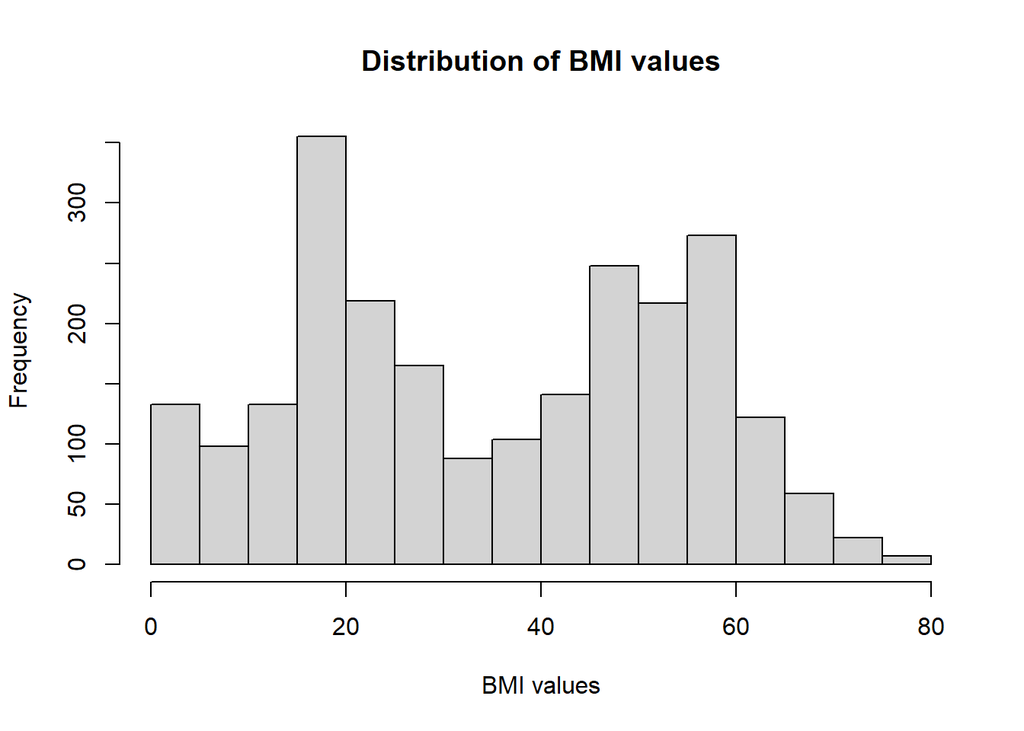

```r
hist(data[which(data$Status == 'Developing'),'BMI'],main = 'Distribution of BMI values',xlab = 'BMI values')
```

We can see that the distribution of the BMI taken for developing countries follows a bimodal distribution. Taking a median of this kind of distribution doesn't seem right.

```r
median(data[which(data$Status == 'Developing'),'BMI'],na.rm = TRUE)
```

```
## [1] 35.15
```

According to world data.com, Sudan male has an average bmi of 23.3 while females have an average bmi of 26. The average of these figures i.e 24.6 is what we will use. Since Sudan and South Sudan were the same country till 2010 and due to unavailability of data and uncertainity of data, we will use the same figure for both sudan and south sudan

```r
data[which(data$Country == 'SouthSudan' | data$Country == 'Sudan'),'BMI'] <- 24.6
```

*Lets look at the remaining columns*

```r
na_columns <- c()
for(i in colnames(data)){
  if(nrow(data[!complete.cases(data[i]),])>0){
    print(paste(i,'has',nrow(data[!complete.cases(data[i]),]),'missing values'))
    na_columns <- append(na_columns,i)
  }
}
```

```
## [1] "Alcohol has 193 missing values"
## [1] "HepatitisB has 553 missing values"
## [1] "Totalexpenditure has 226 missing values"
## [1] "GDP has 443 missing values"
## [1] "Population has 644 missing values"
## [1] "Schooling has 160 missing values"
```

*Now we have 6 columns which large number of missing instances*, **First we will solve for alcohol**

```r
data[!complete.cases(data$Alcohol),c("Country","Status","Year","Alcohol")]
```

```
##                                   Country     Status Year Alcohol
## 33                                Algeria Developing 2015      NA
## 49                                 Angola Developing 2015      NA
## 65                      AntiguaandBarbuda Developing 2015      NA
## 81                              Argentina Developing 2015      NA
## 97                                Armenia Developing 2015      NA
## 113                             Australia  Developed 2015      NA
## 129                               Austria  Developed 2015      NA
## 145                            Azerbaijan Developing 2015      NA
## 161                               Bahamas Developing 2015      NA
## 177                               Bahrain Developing 2015      NA
## 193                            Bangladesh Developing 2015      NA
## 209                              Barbados Developing 2015      NA
## 225                               Belarus Developing 2015      NA
## 241                               Belgium  Developed 2015      NA
```

[output cut: 179 more lines]

It appears as though the recording for alcohol consumption haven't been taken for 2015. Hence it can be solved by taking the average of alcohol consumption of each country from 2000-14.

```r
for(i in unique(data$Country)){
  print(paste(i,':',median(data[which(data$Country == i),"Alcohol"],na.rm = TRUE)))
}
```

```
## [1] "Afghanistan : 0.01"
## [1] "Albania : 4.95"
## [1] "Algeria : 0.45"
## [1] "Angola : 6.35"
## [1] "AntiguaandBarbuda : 7.84"
## [1] "Argentina : 7.93"
## [1] "Armenia : 3.91"
## [1] "Australia : 10.17"
## [1] "Austria : 12.26"
## [1] "Azerbaijan : 0.73"
## [1] "Bahamas : 10.15"
## [1] "Bahrain : 1.99"
## [1] "Bangladesh : 0.01"
## [1] "Barbados : 8.41"
## [1] "Belarus : 13.94"
```

[output cut: 168 more lines]

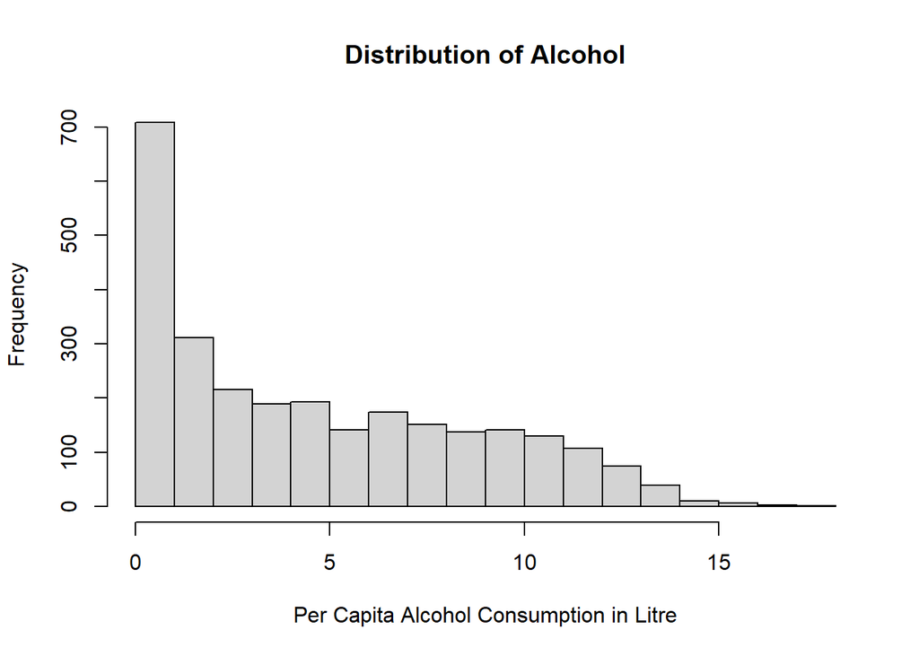

```r
hist(data[complete.cases(data$Alcohol),"Alcohol"],main = 'Distribution of Alcohol',xlab = 'Per Capita Alcohol Consumption in Litre')
```

```r
for(i in unique(data$Country)){
  data[which(data$Country == i & data$Year == '2015'),'Alcohol' ] = median(data[which(data$Country == i),"Alcohol"],na.rm = TRUE)
}

data[!complete.cases(data$Alcohol),c("Country","Status","Year","Alcohol")]
```

```
##         Country     Status Year Alcohol
## 1743 Montenegro Developing 2005      NA
## 2410 SouthSudan Developing 2015      NA
## 2411 SouthSudan Developing 2014      NA
## 2412 SouthSudan Developing 2013      NA
## 2413 SouthSudan Developing 2012      NA
## 2414 SouthSudan Developing 2011      NA
## 2415 SouthSudan Developing 2010      NA
## 2416 SouthSudan Developing 2009      NA
## 2417 SouthSudan Developing 2008      NA
## 2418 SouthSudan Developing 2007      NA
## 2419 SouthSudan Developing 2006      NA
## 2420 SouthSudan Developing 2005      NA
## 2421 SouthSudan Developing 2004      NA
## 2422 SouthSudan Developing 2003      NA
## 2423 SouthSudan Developing 2002      NA
## 2424 SouthSudan Developing 2001      NA
## 2425 SouthSudan Developing 2000      NA
```

We need to replace the missing values of South Sudan and Montenegro

```r
data[which(data$Country == 'SouthSudan'),'Alcohol' ] = median(data[which(data$Country == 'Sudan'),'Alcohol' ],na.rm = TRUE)
data[which(data$Country == 'SouthSudan'),'Alcohol' ] = median(data[which(data$Country == 'Sudan'),'Alcohol' ],na.rm = TRUE)

data[which(data$Country == 'Montenegro' & is.na(data$Alcohol)),'Alcohol' ] = median(data[which(data$Country == 'Montenegro'),'Alcohol'],na.rm = TRUE)
```

*Lets look at the remaining columns*

```r
na_columns <- c()
for(i in colnames(data)){
  if(nrow(data[!complete.cases(data[i]),])>0){
    print(paste(i,'has',nrow(data[!complete.cases(data[i]),]),'missing values'))
    na_columns <- append(na_columns,i)
  }
}
```

```
## [1] "HepatitisB has 553 missing values"
## [1] "Totalexpenditure has 226 missing values"
## [1] "GDP has 443 missing values"
## [1] "Population has 644 missing values"
## [1] "Schooling has 160 missing values"
```

**Now we move to the schooling column**

```r
data[!complete.cases(data$Schooling),c("Country","Year","Status","Schooling")]
```

```
##                                            Country Year     Status Schooling
## 433                                  CÃ´ted'Ivoire 2015 Developing        NA
## 434                                  CÃ´ted'Ivoire 2014 Developing        NA
## 435                                  CÃ´ted'Ivoire 2013 Developing        NA
## 436                                  CÃ´ted'Ivoire 2012 Developing        NA
## 437                                  CÃ´ted'Ivoire 2011 Developing        NA
## 438                                  CÃ´ted'Ivoire 2010 Developing        NA
## 439                                  CÃ´ted'Ivoire 2009 Developing        NA
## 440                                  CÃ´ted'Ivoire 2008 Developing        NA
## 441                                  CÃ´ted'Ivoire 2007 Developing        NA
## 442                                  CÃ´ted'Ivoire 2006 Developing        NA
## 443                                  CÃ´ted'Ivoire 2005 Developing        NA
## 444                                  CÃ´ted'Ivoire 2004 Developing        NA
## 445                                  CÃ´ted'Ivoire 2003 Developing        NA
## 446                                  CÃ´ted'Ivoire 2002 Developing        NA
```

[output cut: 146 more lines]

Now with several countries not having any schooling values for any years, we are going to try to assign them values based on their status and year. First we will need to check if the schooling data for developed and developing nations is normal so that we can take average across all other nations for a given year.

```r
for(i in unique(data$Year)){
    print(paste("Year :",i,"- p value :",shapiro.test(data[which(data$Status == 'Developed' & data$Year == i),'Schooling'])[2]))
}
```

```
## [1] "Year : 2015 - p value : 0.295451415893467"
## [1] "Year : 2014 - p value : 0.338213837511792"
## [1] "Year : 2013 - p value : 0.177087838340299"
## [1] "Year : 2012 - p value : 0.226609824484554"
## [1] "Year : 2011 - p value : 0.192033189124809"
## [1] "Year : 2010 - p value : 0.141210058308648"
## [1] "Year : 2009 - p value : 0.466189620002401"
## [1] "Year : 2008 - p value : 0.402505560453726"
## [1] "Year : 2007 - p value : 0.318805933750593"
## [1] "Year : 2006 - p value : 0.181577794271046"
## [1] "Year : 2005 - p value : 0.310613862191847"
## [1] "Year : 2004 - p value : 0.368774274062041"
## [1] "Year : 2003 - p value : 0.323518165145959"
## [1] "Year : 2002 - p value : 0.625610573384895"
## [1] "Year : 2001 - p value : 0.741180776305096"
## [1] "Year : 2000 - p value : 0.7061800259549"
```

From the above test, we have found that the schooling data for developed nations is normal for all given years. Hence we can take an average of schooling data for a given year and asssign it to developed nations with schooling values.

```r
for(i in unique(data$Year)){
  print(paste("Year :",i,"- p value :",shapiro.test(data[which(data$Status == 'Developing' & data$Year == i),'Schooling'])[2]))
}
```

```
## [1] "Year : 2015 - p value : 0.0381200243013292"
## [1] "Year : 2014 - p value : 0.0321265453662696"
## [1] "Year : 2013 - p value : 0.0213725972147635"
## [1] "Year : 2012 - p value : 0.0288516622509633"
## [1] "Year : 2011 - p value : 0.0224684718947566"
## [1] "Year : 2010 - p value : 0.00156172890342206"
## [1] "Year : 2009 - p value : 0.0035617428667024"
## [1] "Year : 2008 - p value : 0.00363067825442432"
## [1] "Year : 2007 - p value : 0.00587548034911597"
## [1] "Year : 2006 - p value : 0.00776996108520268"
## [1] "Year : 2005 - p value : 0.000529554104783199"
## [1] "Year : 2004 - p value : 0.00137762373640685"
## [1] "Year : 2003 - p value : 0.000450615444844568"
## [1] "Year : 2002 - p value : 0.000520312213275169"
## [1] "Year : 2001 - p value : 0.000522379183097746"
## [1] "Year : 2000 - p value : 7.1405099261662e-06"
```

From the above test for developing nations, we found that the schooling mean overs the years is significantly different from a normal distribution. Therefore we would use median to fill the values

```r
for(i in unique(data$Year)){
  data[which(data$Status == 'Developed' & data$Year == i & is.na(data$Schooling)),'Schooling'] = mean(data[which(data$Status == 'Developed' & data$Year == i ),"Schooling"],na.rm = TRUE)
  data[which(data$Status == 'Developing' & data$Year == i & is.na(data$Schooling)),'Schooling'] = median(data[which(data$Status == 'Developing' & data$Year == i ),"Schooling"],na.rm = TRUE)
}
```

*Lets look at the remaining columns*

```r
na_columns <- c()
for(i in colnames(data)){
  if(nrow(data[!complete.cases(data[i]),])>0){
    print(paste(i,'has',nrow(data[!complete.cases(data[i]),]),'missing values'))
    na_columns <- append(na_columns,i)
  }
}
```

```
## [1] "HepatitisB has 553 missing values"
## [1] "Totalexpenditure has 226 missing values"
## [1] "GDP has 443 missing values"
## [1] "Population has 644 missing values"
```

**Now we will look at GDP**

```r
data[!complete.cases(data$GDP),c("Country","Status","Year","GDP")]
```

```
##                                            Country     Status Year GDP
## 161                                        Bahamas Developing 2015  NA
## 162                                        Bahamas Developing 2014  NA
## 163                                        Bahamas Developing 2013  NA
## 164                                        Bahamas Developing 2012  NA
## 165                                        Bahamas Developing 2011  NA
## 166                                        Bahamas Developing 2010  NA
## 167                                        Bahamas Developing 2009  NA
## 168                                        Bahamas Developing 2008  NA
## 169                                        Bahamas Developing 2007  NA
## 170                                        Bahamas Developing 2006  NA
## 171                                        Bahamas Developing 2005  NA
## 172                                        Bahamas Developing 2004  NA
## 173                                        Bahamas Developing 2003  NA
## 174                                        Bahamas Developing 2002  NA
```

[output cut: 429 more lines]

We can see that we have a couple of countries that do not have any GDP values provided. Most of these countries are developing countries. We will try to apply the same method that we used for filling the missing values

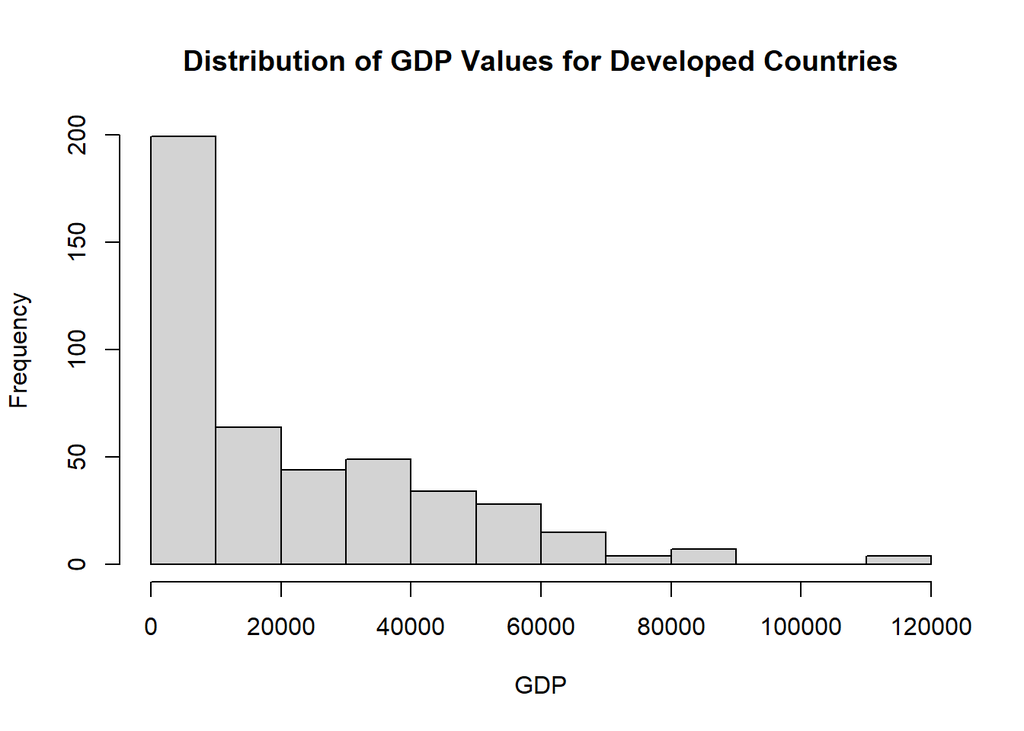

```r
hist(data[which(data$Status == 'Developed' & !is.na(data$GDP)),"GDP"],main = 'Distribution of GDP Values for Developed Countries',xlab = 'GDP')
```

[figure not shown]

```r
hist(data[which(data$Status == 'Developing' & data$Year=="2015" &!is.na(data$GDP)),"GDP"],main = 'Distribution of GDP Values for Developed Countries',xlab = 'GDP')
```

On the whole, we can see that our GDP values for developed and developing countries do not follow a normal distribution. Hence if we wish to fill these values, we need to use the median. However, we will check the GDP for these countries year wise to check if we still get a non-normal distribution

```r
for(i in unique(data$Year)){
  print(paste("Year :",i,"- p value :",shapiro.test(data[which(data$Status == 'Developed' & data$Year == i),'GDP'])[2]))
}
```

```
## [1] "Year : 2015 - p value : 0.000108509616714546"
## [1] "Year : 2014 - p value : 0.000121102564407865"
## [1] "Year : 2013 - p value : 1.2344288972463e-06"
## [1] "Year : 2012 - p value : 0.00181391101075269"
## [1] "Year : 2011 - p value : 0.0072983905919662"
## [1] "Year : 2010 - p value : 0.000578086305749418"
## [1] "Year : 2009 - p value : 0.000672352407588833"
## [1] "Year : 2008 - p value : 0.0393025948631268"
## [1] "Year : 2007 - p value : 0.00932510886314166"
## [1] "Year : 2006 - p value : 0.00917650044572379"
## [1] "Year : 2005 - p value : 0.00627374054114069"
## [1] "Year : 2004 - p value : 0.00139742438262007"
## [1] "Year : 2003 - p value : 1.5182105501921e-05"
## [1] "Year : 2002 - p value : 0.00097976630009033"
## [1] "Year : 2001 - p value : 0.00978611985336714"
## [1] "Year : 2000 - p value : 0.00134577509907917"
```

According to the tests done on the GPD of developed countries for different years, the distribution of gdp values is not normal. Hence, we will use median as our central measure of tendency.

```r
for(i in unique(data$Year)){
  print(paste("Year :",i,"- p value :",shapiro.test(data[which(data$Status == 'Developing' & data$Year == i),'GDP'])[2]))
}
```

```
## [1] "Year : 2015 - p value : 3.75457379671937e-18"
## [1] "Year : 2014 - p value : 3.45312587067937e-18"
## [1] "Year : 2013 - p value : 1.28652438550043e-17"
## [1] "Year : 2012 - p value : 5.10982490974131e-18"
## [1] "Year : 2011 - p value : 1.12201796587688e-19"
## [1] "Year : 2010 - p value : 1.50404324349824e-18"
## [1] "Year : 2009 - p value : 3.78774134193904e-19"
## [1] "Year : 2008 - p value : 1.36223091583058e-19"
## [1] "Year : 2007 - p value : 2.54667895975296e-19"
## [1] "Year : 2006 - p value : 1.48912437626583e-19"
## [1] "Year : 2005 - p value : 3.20192707794672e-19"
## [1] "Year : 2004 - p value : 2.39342121618938e-19"
## [1] "Year : 2003 - p value : 6.35985282485179e-19"
## [1] "Year : 2002 - p value : 3.2880353754962e-19"
## [1] "Year : 2001 - p value : 4.54040738777004e-18"
## [1] "Year : 2000 - p value : 3.57292762900164e-19"
```

According to the tests done on the GPD of developing countries for different years, the distribution of gdp values is not normal. Hence, we will use median as our central measure of tendency.

```r
for(i in unique(data$Year)){
  data[which(data$Status == 'Developed' & data$Year == i & is.na(data$GDP)),'GDP'] = median(data[which(data$Status == 'Developed' & data$Year == i),'GDP'],na.rm = TRUE)
  data[which(data$Status == 'Developing' & data$Year == i & is.na(data$GDP)),'GDP'] = median(data[which(data$Status == 'Developing' & data$Year == i),'GDP'],na.rm = TRUE)
}
```

*Lets look at the remaining columns*

```r
na_columns <- c()
for(i in colnames(data)){
  if(nrow(data[!complete.cases(data[i]),])>0){
    print(paste(i,'has',nrow(data[!complete.cases(data[i]),]),'missing values'))
    na_columns <- append(na_columns,i)
  }
}
```

```
## [1] "HepatitisB has 553 missing values"
## [1] "Totalexpenditure has 226 missing values"
## [1] "Population has 644 missing values"
```

**Now we will look at Total Expenditure**

```r
data[!complete.cases(data$Totalexpenditure),c("Country","Status","Year","Totalexpenditure")]
```

```
##                                            Country     Status Year
## 33                                         Algeria Developing 2015
## 49                                          Angola Developing 2015
## 65                               AntiguaandBarbuda Developing 2015
## 81                                       Argentina Developing 2015
## 97                                         Armenia Developing 2015
## 113                                      Australia  Developed 2015
## 129                                        Austria  Developed 2015
## 145                                     Azerbaijan Developing 2015
## 161                                        Bahamas Developing 2015
## 177                                        Bahrain Developing 2015
## 193                                     Bangladesh Developing 2015
## 209                                       Barbados Developing 2015
## 225                                        Belarus Developing 2015
## 241                                        Belgium  Developed 2015
```

[output cut: 439 more lines]

We can see that the predominant share of missing values relate to the year 2015.

```r
median(data[which(data$Country == 'UnitedStatesofAmerica'),'Totalexpenditure'],na.rm = TRUE)
```

```
## [1] 15.6
```

```r
countries_to_seperate <- c("DemocraticPeople'sRepublicofKorea",'Iraq','Somalia')
countries_to_seperate
```

```
## [1] "DemocraticPeople'sRepublicofKorea" "Iraq"
## [3] "Somalia"
```

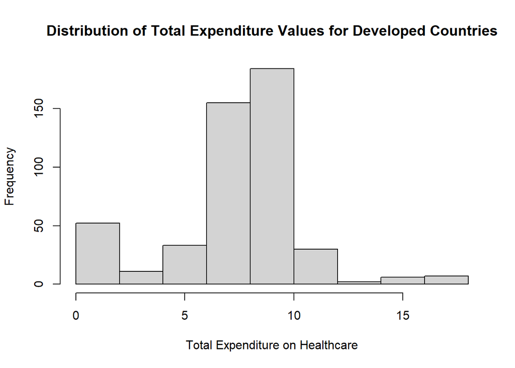

```r
hist(data[which(data$Status == 'Developed'),'Totalexpenditure'],main = 'Distribution of Total Expenditure Values for Developed Countries',xlab = 'Total Expenditure on Healthcare')
```

[figure not shown]

```r
hist(data[which(data$Status == 'Developing'),'Totalexpenditure'],main = 'Distribution of Total Expenditure Values for Developed Countries',xlab = 'Total Expenditure on Healthcare')
```

```r
summary(data[which(data$Status == 'Developed'),'Totalexpenditure'])
```

```
##    Min. 1st Qu.  Median    Mean 3rd Qu.    Max.    NA's
##   1.100   6.407   7.895   7.554   9.213  17.600      32
```

```r
summary(data[which(data$Status == 'Developing'),'Totalexpenditure'])
```

```
##    Min. 1st Qu.  Median    Mean 3rd Qu.    Max.    NA's
##   0.370   4.140   5.400   5.579   6.830  14.390     194
```

```r
for(i in unique(data[which(data$Status == 'Developed'& data$Country != "DemocraticPeople'sRepublicofKorea" & data$Country != "Iraq"& data$Country != "Somalia"& data$Country != "SouthSudan"),'Country'])){
  print(paste("Country :",i,"- p value :",shapiro.test(data[which(data$Country == i & data$Status == 'Developed'),'Totalexpenditure'])[2]))
}
```

```
## [1] "Country : Australia - p value : 0.0875473405119973"
## [1] "Country : Austria - p value : 5.40206308415831e-05"
## [1] "Country : Belgium - p value : 0.000315135530872177"
## [1] "Country : Bulgaria - p value : 0.55601628763009"
## [1] "Country : Croatia - p value : 0.191906172240753"
## [1] "Country : Cyprus - p value : 0.110688651771408"
## [1] "Country : Czechia - p value : 0.521221646975219"
## [1] "Country : Denmark - p value : 0.00108835348799314"
## [1] "Country : Germany - p value : 3.11383556044096e-05"
## [1] "Country : Hungary - p value : 0.286893260262662"
## [1] "Country : Iceland - p value : 1.42859073860093e-06"
## [1] "Country : Ireland - p value : 0.990773972514196"
## [1] "Country : Italy - p value : 0.137186938673442"
## [1] "Country : Japan - p value : 0.000349115186908941"
## [1] "Country : Latvia - p value : 0.968808211809154"
```

[output cut: 17 more lines]

According to the tests done on the total expenditure of developed countries for different years, majority of the expenditures indicate normal. Hence, we will use mean as our central measure of tendency.

```r
for(i in unique(data[which(data$Status == 'Developing'& data$Country != "DemocraticPeople'sRepublicofKorea" & data$Country != "Iraq"& data$Country != "Somalia"& data$Country != "SouthSudan"),'Country'])){
  print(paste("Country :",i,"- p value :",shapiro.test(data[which(data$Country == i),'Totalexpenditure'])[2]))
}
```

```
## [1] "Country : Afghanistan - p value : 0.934528573612463"
## [1] "Country : Albania - p value : 0.851711256159574"
## [1] "Country : Algeria - p value : 0.0144226412893623"
## [1] "Country : Angola - p value : 0.585114939789359"
## [1] "Country : AntiguaandBarbuda - p value : 0.02457732105638"
## [1] "Country : Argentina - p value : 0.461383413102695"
## [1] "Country : Armenia - p value : 0.318213748243121"
## [1] "Country : Azerbaijan - p value : 0.0970203515958121"
## [1] "Country : Bahamas - p value : 0.0103937325274767"
## [1] "Country : Bahrain - p value : 0.0735432629655138"
## [1] "Country : Bangladesh - p value : 0.0409280345540064"
## [1] "Country : Barbados - p value : 0.0419138826934562"
## [1] "Country : Belarus - p value : 0.0766178513244042"
## [1] "Country : Belize - p value : 0.00978076674722632"
## [1] "Country : Benin - p value : 0.366808529591222"
```

[output cut: 132 more lines]

According to the tests done on the total expenditure of developing countries for different years, majority of the expenditures values are normal. Hence, we will use mean as our central measure of tendency.

Before proceeding, we will first sort out the instances for SouthSudan

```r
data[which(data$Country == 'SouthSudan'),'Totalexpenditure'][5:16] <- data[which(data$Country == 'Sudan'),'Totalexpenditure'][5:16]

for(i in unique(data[which(data$Status == 'Developed'& data$Country != "DemocraticPeople'sRepublicofKorea" & data$Country != "Iraq"& data$Country != "Somalia"& data$Country != "SouthSudan"),'Country'])){
  data[which(data$Country == i & data$Year == "2015"),'Totalexpenditure'] <- mean(data[which(data$Country == i),'Totalexpenditure'],na.rm = TRUE)

}


for(i in unique(data[which(data$Status == 'Developing'& data$Country != "DemocraticPeople'sRepublicofKorea" & data$Country != "Iraq"& data$Country != "Somalia"),'Country'])){
  data[which(data$Country == i & data$Year == "2015"),'Totalexpenditure'] <- mean(data[which(data$Country == i),'Totalexpenditure'],na.rm = TRUE)

}

data[!complete.cases(data$Totalexpenditure),c("Country","Status","Year","Totalexpenditure")]
```

```
##                                Country     Status Year Totalexpenditure
## 706  DemocraticPeople'sRepublicofKorea Developing 2015               NA
## 707  DemocraticPeople'sRepublicofKorea Developing 2014               NA
## 708  DemocraticPeople'sRepublicofKorea Developing 2013               NA
## 709  DemocraticPeople'sRepublicofKorea Developing 2012               NA
## 710  DemocraticPeople'sRepublicofKorea Developing 2011               NA
## 711  DemocraticPeople'sRepublicofKorea Developing 2010               NA
## 712  DemocraticPeople'sRepublicofKorea Developing 2009               NA
## 713  DemocraticPeople'sRepublicofKorea Developing 2008               NA
## 714  DemocraticPeople'sRepublicofKorea Developing 2007               NA
## 715  DemocraticPeople'sRepublicofKorea Developing 2006               NA
## 716  DemocraticPeople'sRepublicofKorea Developing 2005               NA
## 717  DemocraticPeople'sRepublicofKorea Developing 2004               NA
## 718  DemocraticPeople'sRepublicofKorea Developing 2003               NA
## 719  DemocraticPeople'sRepublicofKorea Developing 2002               NA
```

[output cut: 22 more lines]

*Lets look at the remaining columns*

```r
for(i in colnames(data)){
  if(nrow(data[!complete.cases(data[i]),])>0){
    print(paste(i,'has',nrow(data[!complete.cases(data[i]),]),'missing values'))
  }
}
```

```
## [1] "HepatitisB has 553 missing values"
## [1] "Totalexpenditure has 36 missing values"
## [1] "Population has 644 missing values"
```

```r
data[which(data$Country=='Iraq'),'Totalexpenditure'][14:16] <- mean(data[which(data$Country=='Iraq'),'Totalexpenditure'],na.rm = TRUE)
data[which(data$Country=='Iraq'),'Totalexpenditure'][1] <- mean(data[which(data$Country=='Iraq'),'Totalexpenditure'][1:5],na.rm = TRUE)

for(i in unique(data$Year)){
data[which(data$Year == i & is.na(data$Totalexpenditure)),"Totalexpenditure"] <- mean(data[which(data$Status == 'Developing' & data$Year == i),"Totalexpenditure"],na.rm = TRUE)
}
```

*Lets look at the remaining columns*

```r
for(i in colnames(data)){
  if(nrow(data[!complete.cases(data[i]),])>0){
    print(paste(i,'has',nrow(data[!complete.cases(data[i]),]),'missing values'))
  }
}
```

```
## [1] "HepatitisB has 553 missing values"
## [1] "Population has 644 missing values"
```

**We need to check the Hepatitis B immunizations column**

```r
data[!complete.cases(data$HepatitisB),c("Country","Status","Year","HepatitisB")]
```

```
##                                            Country     Status Year HepatitisB
## 45                                         Algeria Developing 2003         NA
## 46                                         Algeria Developing 2002         NA
## 47                                         Algeria Developing 2001         NA
## 48                                         Algeria Developing 2000         NA
## 58                                          Angola Developing 2006         NA
## 59                                          Angola Developing 2005         NA
## 60                                          Angola Developing 2004         NA
## 61                                          Angola Developing 2003         NA
## 62                                          Angola Developing 2002         NA
## 63                                          Angola Developing 2001         NA
## 64                                          Angola Developing 2000         NA
## 80                               AntiguaandBarbuda Developing 2000         NA
## 95                                       Argentina Developing 2001         NA
## 96                                       Argentina Developing 2000         NA
```

[output cut: 539 more lines]

```r
for(i in unique(data[!complete.cases(data$HepatitisB),"Country"])){
  print(paste(i,'has',nrow(data[which(data$Country == i & is.na(data$HepatitisB)),]),'rows'))
}
```

```
## [1] "Algeria has 4 rows"
## [1] "Angola has 7 rows"
## [1] "AntiguaandBarbuda has 1 rows"
## [1] "Argentina has 2 rows"
## [1] "Australia has 1 rows"
## [1] "Azerbaijan has 2 rows"
## [1] "Bahamas has 1 rows"
## [1] "Bangladesh has 3 rows"
## [1] "Barbados has 1 rows"
## [1] "Benin has 2 rows"
## [1] "BosniaandHerzegovina has 4 rows"
## [1] "BurkinaFaso has 6 rows"
## [1] "Burundi has 4 rows"
## [1] "CÃ´ted'Ivoire has 1 rows"
## [1] "CaboVerde has 2 rows"
```

[output cut: 83 more lines]

```r
data[which(data$Country == 'Sudan'),c("Year","HepatitisB")]
```

```
##      Year HepatitisB
## 2458 2015         93
## 2459 2014         94
## 2460 2013         93
## 2461 2012         92
## 2462 2011         93
## 2463 2010         75
## 2464 2009         72
## 2465 2008         78
## 2466 2007         78
## 2467 2006          6
## 2468 2005         22
## 2469 2004         NA
## 2470 2003         NA
## 2471 2002         NA
## 2472 2001         NA
## 2473 2000         NA
```

```r
data[which(data$Country == 'SouthSudan'),"HepatitisB"][5:11] <- data[which(data$Country == 'Sudan'),'Totalexpenditure'][5:11]

for(i in unique(data[!complete.cases(data$HepatitisB),"Country"])){
  print(paste(i,'has',nrow(data[which(data$Country == i & is.na(data$HepatitisB)),]),'rows'))
}
```

```
## [1] "Algeria has 4 rows"
## [1] "Angola has 7 rows"
## [1] "AntiguaandBarbuda has 1 rows"
## [1] "Argentina has 2 rows"
## [1] "Australia has 1 rows"
## [1] "Azerbaijan has 2 rows"
## [1] "Bahamas has 1 rows"
## [1] "Bangladesh has 3 rows"
## [1] "Barbados has 1 rows"
## [1] "Benin has 2 rows"
## [1] "BosniaandHerzegovina has 4 rows"
## [1] "BurkinaFaso has 6 rows"
## [1] "Burundi has 4 rows"
## [1] "CÃ´ted'Ivoire has 1 rows"
## [1] "CaboVerde has 2 rows"
```

[output cut: 83 more lines]

We need to check the Hepatitis b immunizations across different types of nations - developed and developing

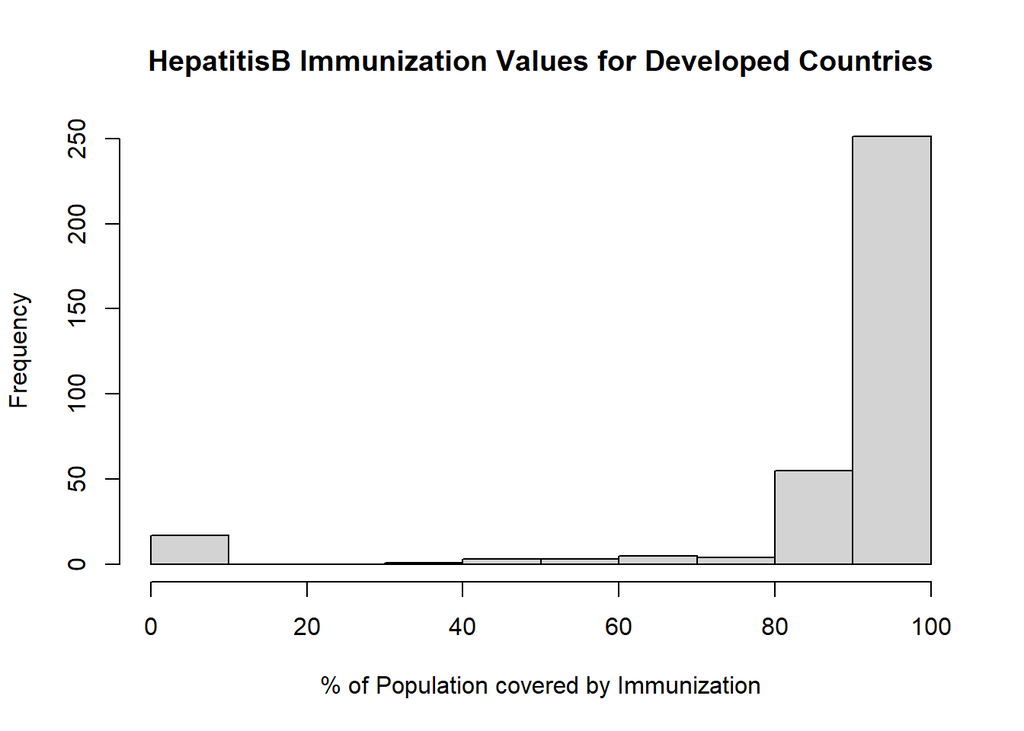

```r
hist(data[which(data$Status == 'Developed'),"HepatitisB"],main = 'HepatitisB Immunization Values for Developed Countries',xlab = '% of Population covered by Immunization')
```

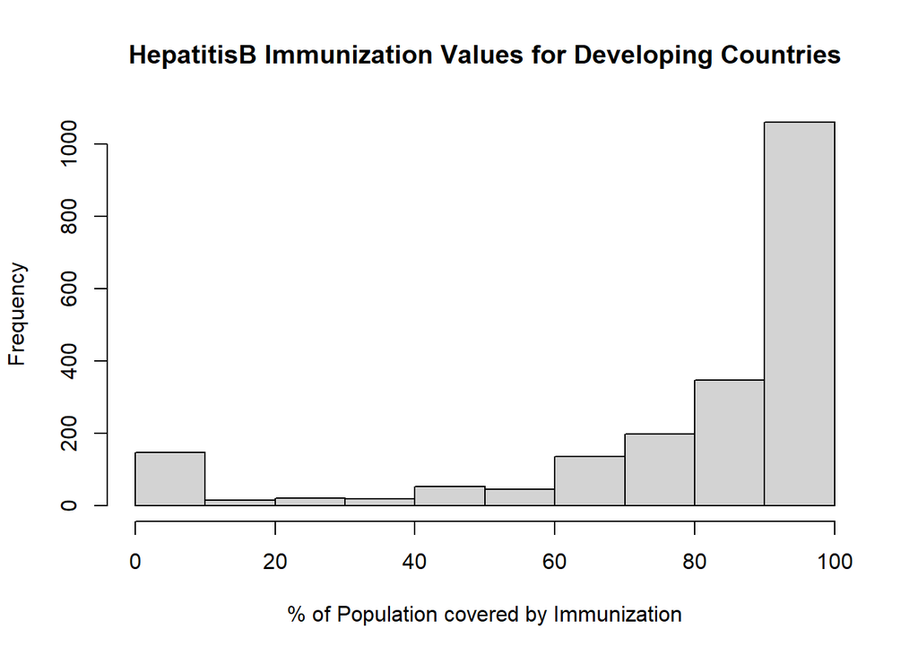

```r
hist(data[which(data$Status == 'Developing'),"HepatitisB"],main = 'HepatitisB Immunization Values for Developing Countries',xlab = '% of Population covered by Immunization')
```

```r
summary(data[which(data$Status == 'Developed'),"HepatitisB"])
```

```
##    Min. 1st Qu.  Median    Mean 3rd Qu.    Max.    NA's
##    2.00   89.00   95.00   88.04   97.00   99.00     173
```

```r
summary(data[which(data$Status == 'Developing'),"HepatitisB"])
```

```
##    Min. 1st Qu.  Median    Mean 3rd Qu.    Max.    NA's
##    1.00   74.50   91.00   79.53   96.50   99.00     373
```

For countries with 5 or less instances of missing immunization values, will use the median values of their other years to fill.

```r
for(i in unique(data[!complete.cases(data$HepatitisB),"Country"])){
  if(nrow(data[which(data$Country == i & is.na(data$HepatitisB)),]) < 6){
    data[which(data$Country == i & is.na(data$HepatitisB)),"HepatitisB"] <- median(data[which(data$Country == i),"HepatitisB"],na.rm = TRUE)
  }
}
```

For countries with more than 5 instances of missing immunization values, we will use take median values of the different years for developed and developing countries.

```r
for(i in data[which(is.na(data$HepatitisB)),"Year"]){
  data[which(data$Year == i & data$Status == 'Developed' &is.na(data$HepatitisB)),"HepatitisB"] <- median(data[which(data$Year==i & data$Status == 'Developed'),"HepatitisB"],na.rm = TRUE)
  data[which(data$Year == i & data$Status == 'Developing' &is.na(data$HepatitisB)),"HepatitisB"] <- median(data[which(data$Year==i & data$Status == 'Developing'),"HepatitisB"],na.rm = TRUE)
}
```

*Lets look at the remaining columns*

```r
for(i in colnames(data)){
  if(nrow(data[!complete.cases(data[i]),])>0){
    print(paste(i,'has',nrow(data[!complete.cases(data[i]),]),'missing values'))
  }
}
```

```
## [1] "Population has 644 missing values"
```

**the last column to correct is population**

```r
data[which(is.na(data$Population)),c('Country','Status','Year','Population')]
```

```
##                                            Country     Status Year Population
## 65                               AntiguaandBarbuda Developing 2015         NA
## 66                               AntiguaandBarbuda Developing 2014         NA
## 67                               AntiguaandBarbuda Developing 2013         NA
## 68                               AntiguaandBarbuda Developing 2012         NA
## 69                               AntiguaandBarbuda Developing 2011         NA
## 70                               AntiguaandBarbuda Developing 2010         NA
## 71                               AntiguaandBarbuda Developing 2009         NA
## 72                               AntiguaandBarbuda Developing 2008         NA
## 73                               AntiguaandBarbuda Developing 2007         NA
## 74                               AntiguaandBarbuda Developing 2006         NA
## 75                               AntiguaandBarbuda Developing 2005         NA
## 76                               AntiguaandBarbuda Developing 2004         NA
## 77                               AntiguaandBarbuda Developing 2003         NA
## 78                               AntiguaandBarbuda Developing 2002         NA
```

[output cut: 630 more lines]

```r
for(i in unique(data[!complete.cases(data$Population),"Country"])){
  print(paste(i,'has',nrow(data[which(data$Country == i & is.na(data$Population)),]),'missing population instances'))
}
```

```
## [1] "AntiguaandBarbuda has 16 missing population instances"
## [1] "Bahamas has 16 missing population instances"
## [1] "Bahrain has 16 missing population instances"
## [1] "Barbados has 16 missing population instances"
## [1] "Bolivia(PlurinationalStateof) has 16 missing population instances"
## [1] "BruneiDarussalam has 16 missing population instances"
## [1] "CÃ´ted'Ivoire has 16 missing population instances"
## [1] "Congo has 16 missing population instances"
## [1] "Cuba has 16 missing population instances"
## [1] "Czechia has 16 missing population instances"
## [1] "DemocraticPeople'sRepublicofKorea has 16 missing population instances"
## [1] "DemocraticRepublicoftheCongo has 16 missing population instances"
## [1] "Egypt has 16 missing population instances"
## [1] "Eritrea has 4 missing population instances"
## [1] "Gambia has 16 missing population instances"
```

[output cut: 26 more lines]

Population is an important variable for the analysis. Each country's population is distinct and cannot be filled using median, mean or using another calculation. Hence, we will try to fill these values manually, by searching the internet and searching for the populations of these countries. Since it would be difficult to gather population data for so many missing instances, we will only fill the missing population instances for 2015, which is the latest year in the dataset.

```r
Population_2015 <- c(93566,353658,1234571,276300,10426154,414400,21570746,76244532,11241161,10506813,25183832,76244544,83483000,5223994,1750732,109553,79109272,3566437,5418300,6230200,6545619,2052722,102624,4367800,2773479,1699435,3758678,174000,109284,27136977,5076700,5424925,2046976,9358602,8264070,64715810,51482637,321418820,28833845,91508084,23153982)

data[which(data$Year == "2015" & is.na(data$Population)),'Population'] <- Population_2015
```

### Answering the Given Questions

Now that we have finished cleaning the data and removing missing instances as much as possible, its time to answer the important questions. We will answer these quetions using data only for the year 2015.

```r
library(ggplot2)
```

**Q1 - Does various predicting factors which has been chosen initially really affect the Life expectancy? What are the predicting variables actually affecting the life expectancy?**

This is a question that we would try to answer towards the end of the analysis.

**Q2 - Should a country having a lower life expectancy value(<65) increase its healthcare expenditure in order to improve its average lifespan?**

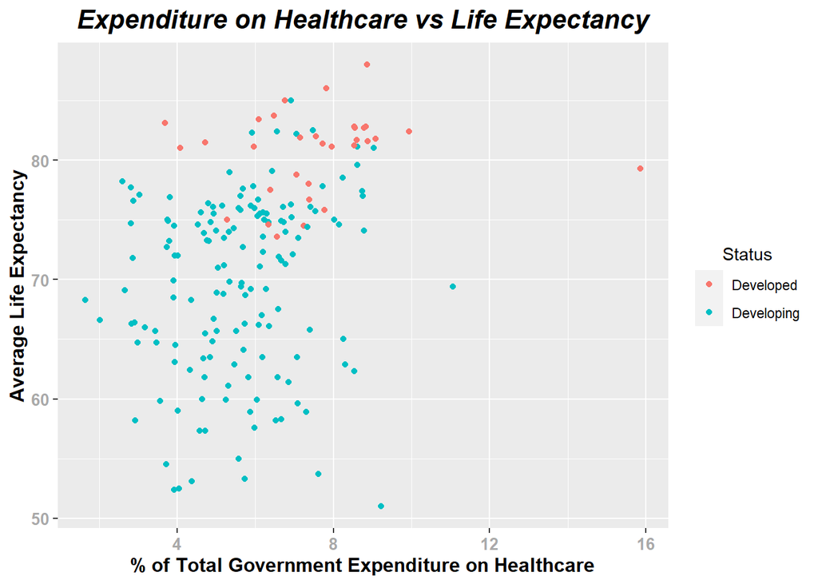

```r
ggplot(data=data[which(data$Year == '2015'),],aes(y= Lifeexpectancy, x = Totalexpenditure)) + geom_point(aes(color = Status))+ labs(title ='Expenditure on Healthcare vs Life Expectancy',x = '% of Total Government Expenditure on Healthcare', y= 'Average Life Expectancy') + theme(plot.title = element_text(size = 16,hjust = 0.5,face = 'bold.italic'),axis.text = element_text(size = 10,face = 'bold',colour = 'darkgrey'),axis.title.x = element_text(size = 12,face = 'bold'),axis.title.y = element_text(size = 12,face = 'bold'),legend.title.align = 0.5)
```

Based on the scatterplot, we can state that there is no apparent postive relation between total healthcare expenditure and life expectancy. A dominant share of Countries with high life expectancy are channeling the same % of the government expenditure towards healthcare as the countries with life expectancy lower than 65. Hence, we can state that life expectancy has more to do than just with healthcare expenditure. We can also see that most of the developed countries with life expectancy above 70 spend on healthcare almost similar to developing nations with lower life expectancy.

**Q3 - How does Infant and Adult mortality rates affect life expectancy?**

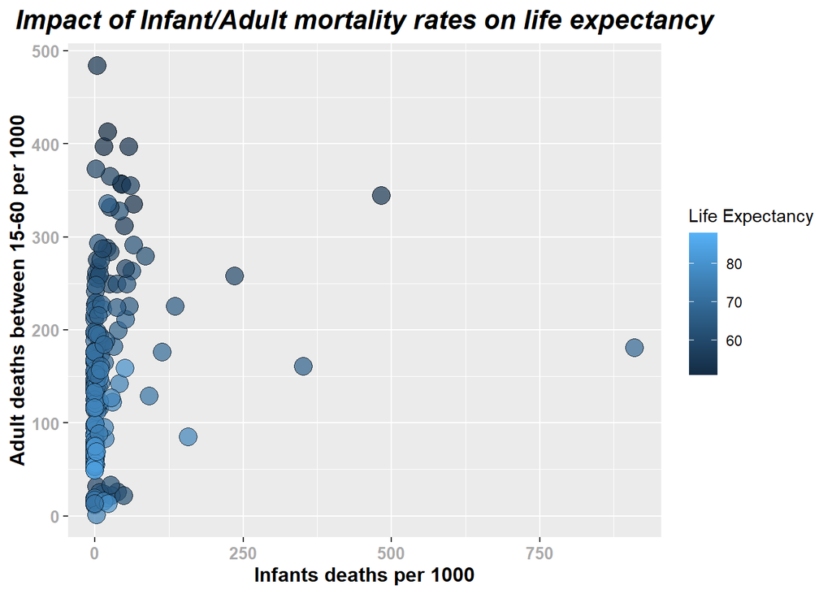

```r
ggplot(data=data[which(data$Year == '2015'),],aes(y= AdultMortality, x = infantdeaths)) + geom_point(aes(fill = Lifeexpectancy),size = 5,pch = 21,alpha = 0.7,colour = "black")+ labs(title ="Impact of Infant/Adult mortality rates on life expectancy",x = 'Infants deaths per 1000', y= 'Adult deaths between 15-60 per 1000') + theme(plot.title = element_text(size = 16,hjust = 0.5,face = 'bold.italic'),axis.text = element_text(size = 10,face = 'bold',colour = 'darkgrey'),axis.title.x = element_text(size = 12,face = 'bold'),axis.title.y = element_text(size = 12,face = 'bold'),legend.title.align = 0.5)+scale_fill_continuous(name = 'Life Expectancy')
```

From the scatterplot, firstly we can conclude that, as of 2015, most countries usually record exceptionally low infant death rates. Very few countries have gone past 100 deaths, which may need to be investigated. However, the adult deaths vary. Back to question, we can state that countries with a very low infants deaths and adult deaths below 150 seem to have an average life expectancy of above 75. Hence, the main target should be looking after the health of the adults in the country as lower adult deaths will significantly improve the life expectancy.

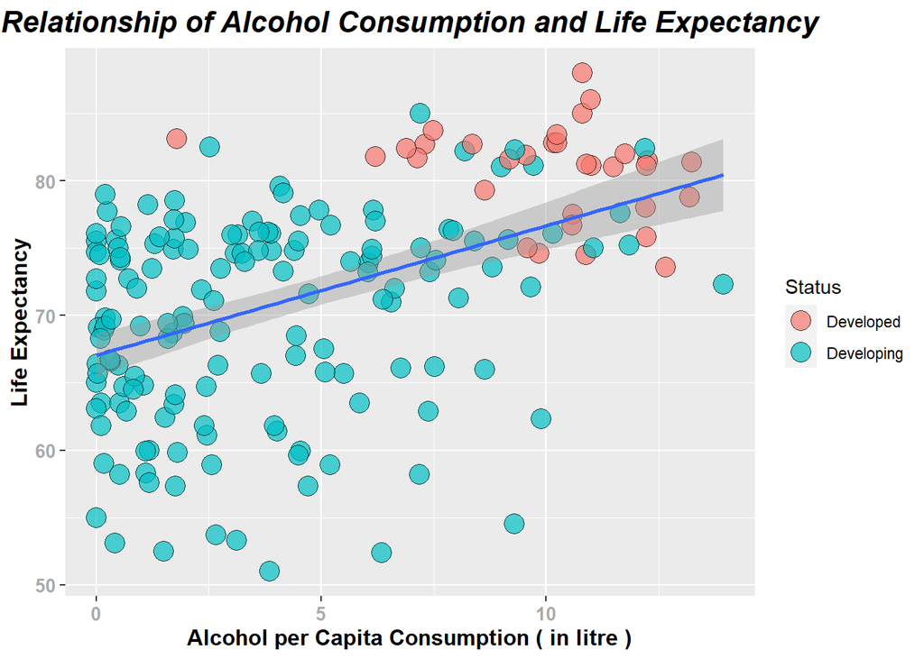

```r
ggplot(data=data[which(data$Year == '2015'),],aes(x= Alcohol, y = Lifeexpectancy)) + geom_point(aes(fill = Status),size = 5,pch = 21,alpha = 0.7,colour = "black")+ labs(title ="Relationship of Alcohol Consumption and Life Expectancy",y = 'Life Expectancy', x= 'Alcohol per Capita Consumption ( in litre )') + theme(plot.title = element_text(size = 16,hjust = 0.5,face = 'bold.italic'),axis.text = element_text(size = 10,face = 'bold',colour = 'darkgrey'),axis.title.x = element_text(size = 12,face = 'bold'),axis.title.y = element_text(size = 12,face = 'bold')) + geom_smooth(method = 'lm')
```

**Q5 - What is the impact of schooling on the lifespan of humans?**

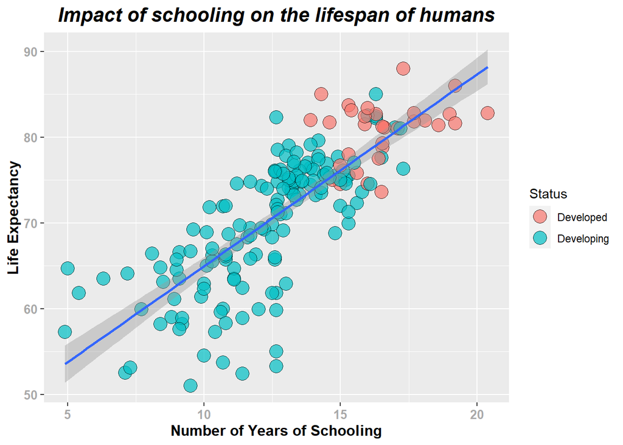

```r
ggplot(data=data[which(data$Year == '2015'),],aes(x = Schooling, y = Lifeexpectancy)) + geom_point(aes(fill = Status),size = 5,pch = 21,alpha = 0.7,colour = "black")+ labs(title = "Impact of schooling on the lifespan of humans",y = 'Life Expectancy', x= 'Number of Years of Schooling') + theme(plot.title = element_text(size = 16,hjust = 0.5,face = 'bold.italic'),axis.text = element_text(size = 10,face = 'bold',colour = 'darkgrey'),axis.title.x = element_text(size = 12,face = 'bold'),axis.title.y = element_text(size = 12,face = 'bold')) + geom_smooth(method = 'lm')
```

From the scatter plot, we can catch a clear and a very strong positive correlation between Numbers of Years of Schooliing and Life Expectancy. Countries where people get more years of schooling record very high life expectancy. Hence, we can definitely consider schooling as an important predictor.

**Q6 - Do densely populated countries tend to have lower life expectancy?**

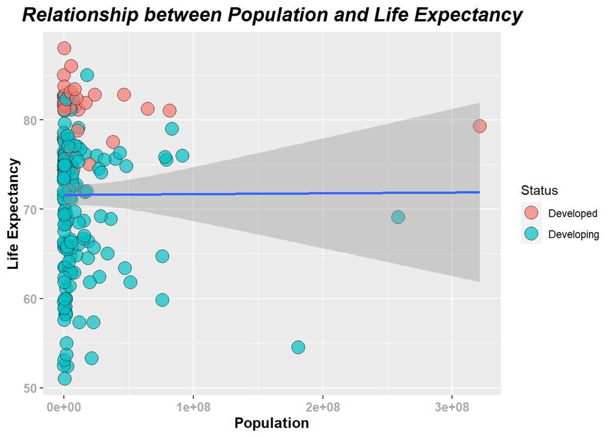

```r
ggplot(data=data[which(data$Year == '2015'),],aes(x = Population, y = Lifeexpectancy)) + geom_point(aes(fill = Status),size = 5,pch = 21,alpha = 0.7,colour = "black")+ labs(title = "Relationship between Population and Life Expectancy" ,y = 'Life Expectancy', x= 'Population') + theme(plot.title = element_text(size = 16,hjust = 0.5,face = 'bold.italic'),axis.text = element_text(size = 10,face = 'bold',colour = 'darkgrey'),axis.title.x = element_text(size = 12,face = 'bold'),axis.title.y = element_text(size = 12,face = 'bold')) + geom_smooth(method = 'lm')
```

From the scatterplot, we can conclude that there is no apparent correlation between population and life expectancy. There are many densely populated countries with high life expectancy and low life expectancy. There are cases of countries with extremely large populations and high and low life expectancy. However, on mapping status of countires, it also be seen that even developed countries with large populations, similiar to those of developing countries, have very high life expectancy. Hence, we can state that simply having a large population can't be a reason for having lower life expectancy.

**Q7 - What is the impact of Immunization coverage on life Expectancy?**

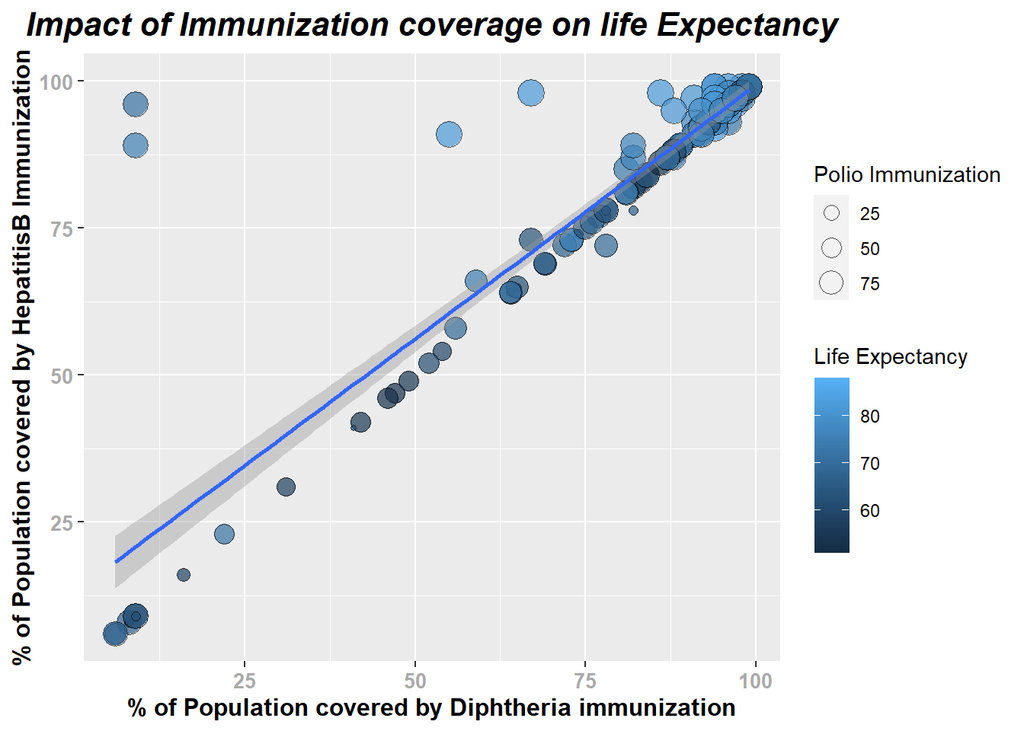

```r
ggplot(data=data[which(data$Year == '2015'),],aes(x = HepatitisB, y = Diphtheria)) + geom_point(aes(size = Polio,fill = Lifeexpectancy),pch = 21,alpha = 0.7,colour = "black")+ labs(title = "Impact of Immunization coverage on life Expectancy" ,y = "% of Population covered by HepatitisB Immunization", x= "% of Population covered by Diphtheria immunization") + theme(plot.title = element_text(size = 16,hjust = 0.5,face = 'bold.italic'),axis.text = element_text(size = 10,face = 'bold',colour = 'darkgrey'),axis.title.x = element_text(size = 12,face = 'bold'),axis.title.y = element_text(size = 12,face = 'bold')) + geom_smooth(method = 'lm') + scale_fill_continuous(name = 'Life Expectancy') + guides(size = guide_legend('Polio Immunization'))
```

From the scatterplot, we can see that there is a very positive relationship between immunization rates and Life expectancy. Countries which are working hard on providing immunization against diseases like HepatitisB, Diphtheria and Polion to large share of their population record very high life expectancies. Therefore, Immunization does a play a crucial role in determining the life expectancy of a country.

**Getting back to our first question** **Q1 - Does various predicting factors which has been chosen initially really affect the Life expectancy? What are the predicting variables actually affecting the life expectancy?**

```r
model = lm(Lifeexpectancy~AdultMortality+infantdeaths+Alcohol+Totalexpenditure+HepatitisB+Measles+BMI+under.fivedeaths+Polio+Totalexpenditure+Diphtheria+HIV.AIDS+GDP+Population+Schooling,data = data[which(data$Year == "2015"),])
summary(model)
```

```
##
## Call:
## lm(formula = Lifeexpectancy ~ AdultMortality + infantdeaths +
##     Alcohol + Totalexpenditure + HepatitisB + Measles + BMI +
##     under.fivedeaths + Polio + Totalexpenditure + Diphtheria +
##     HIV.AIDS + GDP + Population + Schooling, data = data[which(data$Year ==
##     "2015"), ])
##
## Residuals:
##    Min     1Q Median     3Q    Max
## -9.610 -1.858  0.034  2.122  8.076
##
## Coefficients:
##                    Estimate Std. Error t value Pr(>|t|)
## (Intercept)       5.728e+01  2.061e+00  27.801  < 2e-16 ***
## AdultMortality   -3.233e-02  3.668e-03  -8.815 1.46e-15 ***
## infantdeaths      7.642e-02  3.534e-02   2.162  0.03201 *
## Alcohol           1.364e-01  8.752e-02   1.559  0.12094
## Totalexpenditure  1.570e-01  1.538e-01   1.021  0.30869
## HepatitisB        2.292e-02  2.699e-02   0.849  0.39703
## Measles          -1.814e-05  6.085e-05  -0.298  0.76595
## BMI               1.511e-02  1.516e-02   0.997  0.32038
## under.fivedeaths -6.151e-02  2.606e-02  -2.360  0.01941 *
## Polio             2.181e-02  1.458e-02   1.496  0.13648
## Diphtheria        6.905e-03  3.091e-02   0.223  0.82352
## HIV.AIDS         -6.688e-01  2.558e-01  -2.615  0.00975 **
## GDP               4.583e-05  2.658e-05   1.724  0.08652 .
## Population        2.101e-09  7.537e-09   0.279  0.78080
## Schooling         1.003e+00  1.500e-01   6.687 3.23e-10 ***
## ---
## Signif. codes:  0 '***' 0.001 '**' 0.01 '*' 0.05 '.' 0.1 ' ' 1
##
## Residual standard error: 3.342 on 168 degrees of freedom
## Multiple R-squared:  0.8438, Adjusted R-squared:  0.8308
## F-statistic: 64.83 on 14 and 168 DF,  p-value: < 2.2e-16
```

However, based on the insights that we derived from answering the important questions, lets use the variables of Schooling, HepatitisB , Diphtheria, Polio and Adult Mortality for understanding the relationship with life expectancy.

```r
model1 = lm(Lifeexpectancy~Schooling + HepatitisB + Diphtheria + Polio + AdultMortality,data = data[which(data$Year == "2015"),] )
summary(model1)
```

```
##
## Call:
## lm(formula = Lifeexpectancy ~ Schooling + HepatitisB + Diphtheria +
##     Polio + AdultMortality, data = data[which(data$Year == "2015"),
##     ])
##
## Residuals:
##      Min       1Q   Median       3Q      Max
## -10.2365  -1.8316   0.1336   2.2482   7.4026
##
## Coefficients:
##                Estimate Std. Error t value Pr(>|t|)
## (Intercept)    54.98675    1.87926  29.260   <2e-16 ***
## Schooling       1.31019    0.11173  11.726   <2e-16 ***
## HepatitisB      0.01672    0.02738   0.611   0.5421
## Diphtheria      0.02196    0.03139   0.700   0.4850
## Polio           0.02806    0.01456   1.927   0.0556 .
## AdultMortality -0.03893    0.00320 -12.167   <2e-16 ***
## ---
## Signif. codes:  0 '***' 0.001 '**' 0.01 '*' 0.05 '.' 0.1 ' ' 1
##
## Residual standard error: 3.458 on 177 degrees of freedom
## Multiple R-squared:  0.8237, Adjusted R-squared:  0.8188
## F-statistic: 165.5 on 5 and 177 DF,  p-value: < 2.2e-16
```